# KernelEstimate: Predicting Home Sale Prices

## Introduction

In this report, I developed a model that estimates the sale price of homes based on key property features like Lot Frontage, Sale Type, and various structural and neighborhood characteristics. This model aims to create an accurate KernelEstimate model for CornHawkHomes that reduces prediction errors and provides users with reliable guidance when evaluating homes specifically in the Ames, Iowa market. Using residential sales data from 2006–2010, I preprocess numerical and categorical variables and train a tuned Random Forest regression model within a complete machine learning pipeline. I evaluate the model using Mean Absolute Percentage Error (MAPE) and the proportion of predictions within 20% of the true sale price, ensuring the final model meets the performance standards required for production deployment.

## Methods

To develop the KernelEstimate model, I constructed a preprocessing and modeling pipeline that handled numerical features directly and applied one-hot encoding to categorical features. I initially considered multiple regression approaches, including linear models and tree-based methods, and selected Random Forest as the primary model due to its strong performance on nonlinear relationships and mixed feature types. I tuned the Random Forest’s key parameters—number of trees, maximum depth, and minimum samples per split—using GridSearchCV with three-fold cross-validation.Model selection was guided by a custom scoring function that measured the proportion of predictions falling within 20% of the true sale price. After tuning, the final model’s performance was evaluated on the test set using this metric alongside Mean Absolute Percentage Error (MAPE).

### Data

The dataset used in this project includes 1,875 residential properties sold in Ames, Iowa between 2006 and 2010, with each row representing a single home. Each property is described by 81 features capturing lot size, structural characteristics, quality and condition ratings, neighborhood information, and relevant sale details, while the target variable SalePrice records the final sale price in U.S. dollars. The data is provided in predefined training and test splits, with an additional production set reserved for final evaluation. These data are derived from the Ames Housing dataset introduced by De Cock (2011) and have been adapted for building and validating the KernelEstimate home price prediction model.

### Variable Descriptions

SalePrice (int64): Sale price in USD.

Order (int64): Observation number.

PID (int64): Parcel identification number; can be used with city resources for parcel review.

MS SubClass (int64): Type of dwelling involved in the sale.

MS Zoning (object): General zoning classification of the sale.

Lot Frontage (float64): Linear feet of street connected to the property.

Lot Area (int64): Lot size in square feet.

Street (object): Type of road access to the property.

Alley (object): Type of alley access to the property.

Lot Shape (object): General shape of the property.

Land Contour (object): Flatness of the property.

Utilities (object): Type of utilities available.

Lot Config (object): Lot configuration.

Land Slope (object): Slope of the property.

Neighborhood (object): Physical location within Ames city limits.

Condition 1 (object): Proximity to various environmental or infrastructure conditions.

Condition 2 (object): Additional proximity condition (if more than one is present).

Bldg Type (object): Type of dwelling.

House Style (object): Style of dwelling.

Overall Qual (int64): Overall material and finish quality of the house.

Overall Cond (int64): Overall condition rating of the house.

Year Built (int64): Original construction year.

Year Remod/Add (int64): Year of remodeling or addition (same as construction year if none).

Roof Style (object): Type of roof.

Roof Matl (object): Roofing material.

Exterior 1st (object): Primary exterior covering.

Exterior 2nd (object): Secondary exterior covering (if applicable).

Mas Vnr Type (object): Masonry veneer type.

Mas Vnr Area (float64): Masonry veneer area in square feet.

Exter Qual (object): Exterior material quality.

Exter Cond (object): Exterior material condition.

Foundation (object): Type of foundation.

Bsmt Qual (object): Basement height quality.

Bsmt Cond (object): General condition of the basement.

Bsmt Exposure (object): Basement walkout or garden-level exposure.

BsmtFin Type 1 (object): Rating of primary basement finished area.

BsmtFin SF 1 (float64): Square footage of primary finished basement area.

BsmtFin Type 2 (object): Rating of secondary finished basement area.

BsmtFin SF 2 (float64): Square footage of secondary finished basement area.

Bsmt Unf SF (float64): Unfinished basement square footage.

Total Bsmt SF (float64): Total basement square footage.

Heating (object): Type of heating system.

Heating QC (object): Heating quality and condition.

Central Air (object): Indicates presence of central air conditioning.

Electrical (object): Electrical system type.

1st Flr SF (int64): First-floor area in square feet.

2nd Flr SF (int64): Second-floor area in square feet.

Low Qual Fin SF (int64): Low-quality finished area across all floors.

Gr Liv Area (int64): Above-ground living area in square feet.

Bsmt Full Bath (float64): Basement full bathrooms.

Bsmt Half Bath (float64): Basement half bathrooms.

Full Bath (int64): Full bathrooms above grade.

Half Bath (int64): Half bathrooms above grade.

Bedroom AbvGr (int64): Bedrooms above grade (not including basement bedrooms).

Kitchen AbvGr (int64): Kitchens above grade.

Kitchen Qual (object): Kitchen quality.

TotRms AbvGrd (int64): Total rooms above grade (excluding bathrooms).

Functional (object): Home functionality rating.

Fireplaces (int64): Number of fireplaces.

Fireplace Qu (object): Fireplace quality.

Garage Type (object): Garage location.

Garage Yr Blt (float64): Year the garage was built.

Garage Finish (object): Interior finish of the garage.

Garage Cars (float64): Garage capacity in number of cars.

Garage Area (float64): Garage size in square feet.

Garage Qual (object): Garage quality.

Garage Cond (object): Garage condition.

Paved Drive (object): Paved driveway indicator.

Wood Deck SF (int64): Wood deck area in square feet.

Open Porch SF (int64): Open porch area in square feet.

Enclosed Porch (int64): Enclosed porch area in square feet.

3Ssn Porch (int64): Three-season porch area in square feet.

Screen Porch (int64): Screen porch area in square feet.

Pool Area (int64): Pool area in square feet.

Pool QC (object): Pool quality.

Fence (object): Fence quality.

Misc Feature (object): Miscellaneous feature not covered elsewhere.

Misc Val (int64): Value of the miscellaneous feature.

Mo Sold (int64): Month the home was sold.

Yr Sold (int64): Year the home was sold.

Sale Type (object): Type of sale.

Sale Condition (object): Sale condition.

```
(             Order           PID  MS SubClass  Lot Frontage       Lot Area  \
 count  1875.000000  1.875000e+03  1875.000000   1573.000000    1875.000000
 mean   1456.019733  7.149438e+08    56.469333     69.376987   10139.230400
 std     847.182924  1.887383e+08    41.782438     23.410805    8632.001033
 min       1.000000  5.263011e+08    20.000000     21.000000    1300.000000
 25%     723.500000  5.284562e+08    20.000000     59.000000    7417.500000
 50%    1464.000000  5.354532e+08    50.000000     68.000000    9316.000000
 75%    2181.500000  9.071350e+08    70.000000     80.000000   11381.500000
 max    2928.000000  9.241520e+08   190.000000    313.000000  215245.000000

        Overall Qual  Overall Cond   Year Built  Year Remod/Add  Mas Vnr Area  \
 count   1875.000000   1875.000000  1875.000000     1875.000000   1860.000000
 mean       6.080533      5.558400  1971.738667     1984.570667     98.689785
 std        1.403008      1.081116    30.002347       20.704654    173.084451
 min        1.000000      1.000000  1872.000000     1950.000000      0.000000
 25%        5.000000      5.000000  1954.000000     1966.000000      0.000000
 50%        6.000000      5.000000  1974.000000     1993.000000      0.000000
 75%        7.000000      6.000000  2001.000000     2004.000000    154.500000
 max       10.000000      9.000000  2010.000000     2010.000000   1224.000000

        ...  Wood Deck SF  Open Porch SF  Enclosed Porch   3Ssn Porch  \
 count  ...   1875.000000    1875.000000     1875.000000  1875.000000
 mean   ...     92.329600      48.651200       22.544533     2.274667
 std    ...    123.010868      69.874945       61.543397    23.608845
 min    ...      0.000000       0.000000        0.000000     0.000000
 25%    ...      0.000000       0.000000        0.000000     0.000000
 50%    ...      0.000000      26.000000        0.000000     0.000000
 75%    ...    168.000000      72.000000        0.000000     0.000000
 max    ...    857.000000     742.000000      584.000000   508.000000

        Screen Porch    Pool Area      Misc Val      Mo Sold      Yr Sold  \
 count   1875.000000  1875.000000   1875.000000  1875.000000  1875.000000
 mean      17.079467     2.010133     58.736533     6.203200  2007.802667
 std       58.969355    34.968234    630.158656     2.714401     1.314679
 min        0.000000     0.000000      0.000000     1.000000  2006.000000
 25%        0.000000     0.000000      0.000000     4.000000  2007.000000
 50%        0.000000     0.000000      0.000000     6.000000  2008.000000
 75%        0.000000     0.000000      0.000000     8.000000  2009.000000
 max      576.000000   800.000000  17000.000000    12.000000  2010.000000

```

[output cut: 21 more lines]

```
 freq         1783          270        1602  ...        1094           790

        Garage Qual Garage Cond Paved Drive Pool QC  Fence Misc Feature  \
 count         1771        1771        1875       7    363           71
 unique           5           5           3       3      4            5
 top             TA          TA           Y      Gd  MnPrv         Shed
 freq          1669        1710        1696       4    211           62

        Sale Type Sale Condition
 count       1875           1875
 unique         9              6
 top          WD          Normal
 freq        1620           1530

 [4 rows x 43 columns])
```

The Ames housing dataset contains 1,875 residential properties with a wide range of structural, lot, and quality characteristics. Home sale prices can change substantially, with typical homes selling around the mid-$150,000s and outliers ranging from very low-cost properties to high-value homes above $600,000. Important numeric features like Lot Area, Gr Liv Area, and Total Basement Area show considerable spread and right-skewed distributions, reflecting the diversity of property sizes in Ames. Quality-related variables, such as Overall Qual and Overall Cond, span the full rating scale but cluster around typical mid-level values. Many categorical features like Neighborhood, Exterior Material, and House Style—exhibit multiple unique categories, underscoring the heterogeneity of housing stock across the city. Hence, the data has a mix of numeric and categorical variables that capture meaningful differences between homes, supporting the development of a predictive model for sale prices.

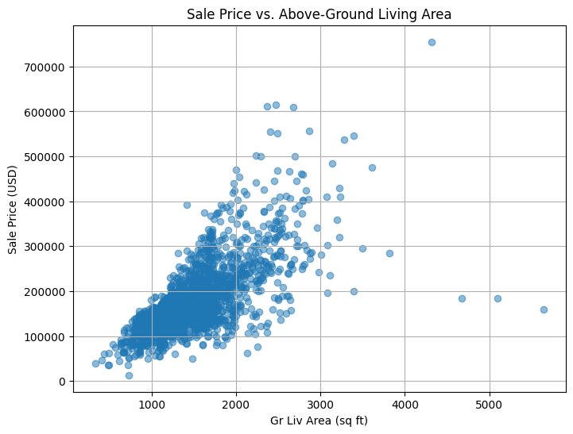

In order to understand the relationship between home characteristics and sale prices, I created a scatterplot of Above-Ground Living Area (Gr Liv Area) versus SalePrice. This visualization shows a strong positive relationship: as living area increases, sale prices generally rise as well. Most homes cluster between 1,000 and 2,500 square feet with sale prices ranging from about $100,000 to $300,000, while larger homes above 3,000 square feet tend to sell for significantly higher prices. The increasing spread at higher square footage also suggests greater variability in prices for larger or higher-end homes. This pattern supports the importance of living area as a key predictor in the model.

### Models

To prepare the data for modeling, I separated the features from the target variable. For both the training and test datasets, SalePrice was extracted as the target (y), while all remaining columns were used as input features (X). This structure follows standard supervised learning practice and allows the model to learn the relationship between home characteristics and their corresponding sale prices.

```
Fitting 3 folds for each of 8 candidates, totalling 24 fits
```

[output not shown]

To train the model, I defined separate feature groups for numerical variables, categorical variables, and fields to exclude. Numerical features were passed through directly, while categorical features were encoded using a one-hot encoder within a preprocessing pipeline. These preprocessing steps were integrated with a Random Forest regressor inside a unified scikit-learn pipeline. I then used GridSearchCV with three-fold cross-validation to tune key hyperparameters—number of trees, maximum depth, and minimum samples required to split a node. Model performance during tuning was evaluated using a custom scoring function that measures the proportion of predictions within 20% of the true sale price. The gridsearch identified the best-performing model, which was then fitted on the full training data.

## Results

```
(np.float64(0.09934703644882574), np.float64(0.908315565031983))
```

After training the model using the tuned Random Forest pipeline, I evaluated its performance on the held-out test dataset. The model achieved a Mean Absolute Percentage Error (MAPE) of approximately 0.099, meaning that on average, predictions differ from the true sale price by about 9.9%. In addition, about 90.8% of predictions fall within 20% of the actual sale price, as measured by the proportion-within-threshold metric.

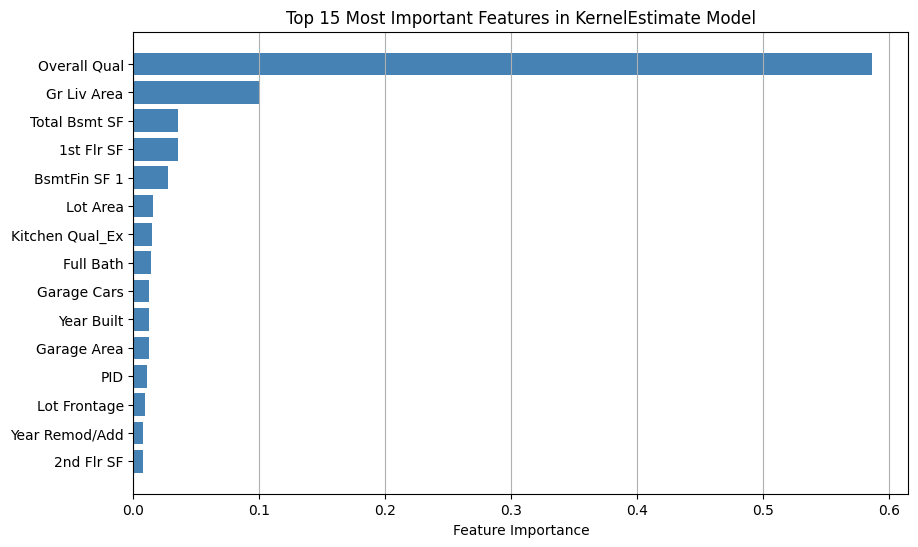

The feature importance plot highlights which variables contributed most to the KernelEstimate model’s predictions. Overall Quality (Overall Qual) is by far the strongest predictor of sale price, reflecting the significant influence of material and finish quality on home valuation. Other important features include above-ground living area (Gr Liv Area), total basement square footage (Total Bsmt SF), first-floor area (1st Flr SF), and finished basement space (BsmtFin SF 1), all of which capture the size and usable living space of a home. Lot-level characteristics like Lot Area, as well as characteristic-specific features like Kitchen Quality, Full Baths, and Garage Cars, also contribute meaningfully. The value of structural and size-related features aligns with real estate domain knowledge, confirming that the model is leveraging the most relevant property characteristics when estimating sale prices.

```
['housing.joblib']
```

## Discussion

The KernelEstimate model demonstrates inredibly strong predictive performance, with approximately 90.8% of test predictions falling within 20% of the true sale price and an average error of about 10%. These results indicate that the model reliably captures the relationships between key home features, such as overall quality, living area, basement size, and year built. along with their contribution to market value. The importance of intuitive predictors and the model’s consistency across the test set suggest that its learned patterns generalize well to typical homes in the Ames housing market. This level of performance aligns with the needs of CornHawkHomes, which works to provide users with quick and informative price estimates similar to Zillow’s Zestimate.

Given these strengths, I would choose to use this model in practice as a consumer-facing valuation tool. The main benefit it provides is that it delivers reasonably accurate, instant estimates that help both buyers and sellers navigate the market. By incorporating multi-dozens of property attributes, the model offers personalized estimates that reflect the nuances of each home. Using this model would increase user engagement, support informed decision-making, and position CornHawkHomes as a competitive platform in the Iowa real estate space. The model’s transparency and feature importance profile also make it easy to interpret and defend, which is essential when presenting estimates to users.

However, the model has limitations that should be acknowledged. A 10% average error means some individual homes—especially outliers, unique properties, or those with rare combinations of features—may receive less reliable predictions. Errors in these cases could mislead users, particularly sellers who may rely heavily on automated estimates to set listing prices. Additionally, the model does not include local market dynamics beyond what is encoded in historical features, meaning sudden market shifts may not be captured. To mitigate these risks, the KernelEstimate should be presented as a starting point, not a replacement for professional appraisal. Future improvements could include experimenting with more advanced algorithms like gradient boosting, integrating neighborhood-level economic indicators, and providing confidence intervals to communicate uncertainty more transparently.